# Project DADM

# 4.3 Hypothesis Testing for Stepwise Regression

No matter how significant a model can be we can still make it better by using Hypothesis testing so that all the co-efficients of variable are significant.

If The below hypothesis holds true as the p-value(ethnicityafam):.78 > .05 Null Hypothesis for X(Limit): H(1): coef(ethnicityafam)=0

We can remove the ethnicity to construct a new model which would have a much better significane

```r
#Remove Ethnicity to construct the model
model2 <- glm(insurance ~ health+age+limit+gender+married+selfemp+family+region+education, family =binomial (link='logit'),data=training)
summary(model2)
```

```
##
## Call:
## glm(formula = insurance ~ health + age + limit + gender + married +
##     selfemp + family + region + education, family = binomial(link = "logit"),
##     data = training)
##
## Deviance Residuals:
##     Min       1Q   Median       3Q      Max
## -2.6665   0.3018   0.4561   0.6572   1.8491
##
## Coefficients:
##                      Estimate Std. Error z value Pr(>|z|)
## (Intercept)         -0.785304   0.224694  -3.495 0.000474 ***
## healthyes            0.373118   0.123496   3.021 0.002517 **
## age                  0.027364   0.003442   7.950 1.87e-15 ***
## limityes            -0.076733   0.101584  -0.755 0.450032
## gendermale          -0.281956   0.069437  -4.061 4.89e-05 ***
## marriedyes           0.942834   0.077926  12.099  < 2e-16 ***
## selfempyes          -1.155650   0.095914 -12.049  < 2e-16 ***
## family              -0.094578   0.021946  -4.310 1.64e-05 ***
## regionmidwest        0.074262   0.114647   0.648 0.517153
## regionsouth         -0.295369   0.100689  -2.933 0.003352 **
## regionwest          -0.397591   0.106031  -3.750 0.000177 ***
## educationged         0.594830   0.158807   3.746 0.000180 ***
## educationhighschool  1.249389   0.091113  13.712  < 2e-16 ***
## educationbachelor    1.762238   0.125728  14.016  < 2e-16 ***
## educationmaster      2.108079   0.225065   9.367  < 2e-16 ***
## educationphd         2.074333   0.384607   5.393 6.91e-08 ***
## educationother       1.423410   0.155134   9.175  < 2e-16 ***
## ---
## Signif. codes:  0 '***' 0.001 '**' 0.01 '*' 0.05 '.' 0.1 ' ' 1
##
## (Dispersion parameter for binomial family taken to be 1)
##
##     Null deviance: 6367.0  on 6401  degrees of freedom
## Residual deviance: 5499.5  on 6385  degrees of freedom
## AIC: 5533.5
##
## Number of Fisher Scoring iterations: 5
```

We can still observe insignificant variables whose values are greater than .05. We’ll apply null hypothesis testing again for model 2 and see that P-value(regionmidwest)>.05.

Hence we remove region variable as well.

```r
#Model after removing region variable
model3 <- glm(insurance ~ health+age+limit+gender+married+selfemp+family+education, family =binomial (link='logit'),data=training)
summary(model3)
```

```
##
## Call:
## glm(formula = insurance ~ health + age + limit + gender + married +
##     selfemp + family + education, family = binomial(link = "logit"),
##     data = training)
##
## Deviance Residuals:
##     Min       1Q   Median       3Q      Max
## -2.6620   0.3140   0.4606   0.6595   1.8364
##
## Coefficients:
##                      Estimate Std. Error z value Pr(>|z|)
## (Intercept)         -1.013380   0.209517  -4.837 1.32e-06 ***
## healthyes            0.382655   0.123099   3.109 0.001880 **
## age                  0.027532   0.003434   8.017 1.08e-15 ***
## limityes            -0.089198   0.101146  -0.882 0.377847
## gendermale          -0.283490   0.069218  -4.096 4.21e-05 ***
## marriedyes           0.940812   0.077608  12.123  < 2e-16 ***
## selfempyes          -1.156233   0.095473 -12.111  < 2e-16 ***
## family              -0.099113   0.021877  -4.530 5.89e-06 ***
## educationged         0.603730   0.158016   3.821 0.000133 ***
## educationhighschool  1.296635   0.090598  14.312  < 2e-16 ***
## educationbachelor    1.805073   0.125199  14.418  < 2e-16 ***
## educationmaster      2.152587   0.224409   9.592  < 2e-16 ***
## educationphd         2.104738   0.383622   5.486 4.10e-08 ***
## educationother       1.490643   0.154195   9.667  < 2e-16 ***
## ---
## Signif. codes:  0 '***' 0.001 '**' 0.01 '*' 0.05 '.' 0.1 ' ' 1
##
## (Dispersion parameter for binomial family taken to be 1)
##
##     Null deviance: 6367.0  on 6401  degrees of freedom
## Residual deviance: 5529.7  on 6388  degrees of freedom
## AIC: 5557.7
##
## Number of Fisher Scoring iterations: 5
```

We remove limit variable as well.

```r
#Model after removing limit variable

model4 <- glm(insurance ~ health+age+gender+married+selfemp+family+education, family =binomial (link='logit'),data=training)
summary(model4)
```

```
##
## Call:
## glm(formula = insurance ~ health + age + gender + married + selfemp +
##     family + education, family = binomial(link = "logit"), data = training)
##
## Deviance Residuals:
##     Min       1Q   Median       3Q      Max
## -2.6538   0.3144   0.4614   0.6589   1.8305
##
## Coefficients:
##                      Estimate Std. Error z value Pr(>|z|)
## (Intercept)         -1.031598   0.208526  -4.947 7.53e-07 ***
## healthyes            0.400621   0.121427   3.299 0.000969 ***
## age                  0.027051   0.003388   7.984 1.42e-15 ***
## gendermale          -0.281960   0.069189  -4.075 4.60e-05 ***
## marriedyes           0.941053   0.077600  12.127  < 2e-16 ***
## selfempyes          -1.155132   0.095451 -12.102  < 2e-16 ***
## family              -0.097188   0.021767  -4.465 8.01e-06 ***
## educationged         0.596891   0.157887   3.780 0.000157 ***
## educationhighschool  1.295902   0.090594  14.304  < 2e-16 ***
## educationbachelor    1.806640   0.125193  14.431  < 2e-16 ***
## educationmaster      2.158476   0.224313   9.623  < 2e-16 ***
## educationphd         2.109208   0.383653   5.498 3.85e-08 ***
## educationother       1.492153   0.154152   9.680  < 2e-16 ***
## ---
## Signif. codes:  0 '***' 0.001 '**' 0.01 '*' 0.05 '.' 0.1 ' ' 1
##
## (Dispersion parameter for binomial family taken to be 1)
##
##     Null deviance: 6367.0  on 6401  degrees of freedom
## Residual deviance: 5530.5  on 6389  degrees of freedom
## AIC: 5556.5
##
## Number of Fisher Scoring iterations: 5
```

We can see that all the variables are significant, so model 4 is the potential model to predcit the response variable.

# 4.4 Partial F-test for Confidence Intervals

```r
anova(model4)
```

```
## Analysis of Deviance Table
##
## Model: binomial, link: logit
##
## Response: insurance
##
## Terms added sequentially (first to last)
##
##
##           Df Deviance Resid. Df Resid. Dev
## NULL                       6401     6367.0
## health     1    19.31      6400     6347.7
## age        1   153.56      6399     6194.2
## gender     1    31.45      6398     6162.7
## married    1   122.15      6397     6040.6
## selfemp    1   119.38      6396     5921.2
## family     1    64.58      6395     5856.6
## education  6   326.11      6389     5530.5
```

```r
lwr <- qf(0, 6388, model4$df.residual)
upr <- qf(0.95, 6388, model4$df.residual)
c(lwr, upr)
```

```
## [1] 0.00000 1.04202
```

So if the z-value falls outside this interval, we could decide that null Hypothesis as false and use alternative hypothesis.

To see the z-value we use the summary() function:

```r
summary(model4)
```

```
##
## Call:
## glm(formula = insurance ~ health + age + gender + married + selfemp +
##     family + education, family = binomial(link = "logit"), data = training)
##
## Deviance Residuals:
##     Min       1Q   Median       3Q      Max
## -2.6538   0.3144   0.4614   0.6589   1.8305
##
## Coefficients:
##                      Estimate Std. Error z value Pr(>|z|)
## (Intercept)         -1.031598   0.208526  -4.947 7.53e-07 ***
## healthyes            0.400621   0.121427   3.299 0.000969 ***
## age                  0.027051   0.003388   7.984 1.42e-15 ***
## gendermale          -0.281960   0.069189  -4.075 4.60e-05 ***
## marriedyes           0.941053   0.077600  12.127  < 2e-16 ***
## selfempyes          -1.155132   0.095451 -12.102  < 2e-16 ***
## family              -0.097188   0.021767  -4.465 8.01e-06 ***
## educationged         0.596891   0.157887   3.780 0.000157 ***
## educationhighschool  1.295902   0.090594  14.304  < 2e-16 ***
## educationbachelor    1.806640   0.125193  14.431  < 2e-16 ***
## educationmaster      2.158476   0.224313   9.623  < 2e-16 ***
## educationphd         2.109208   0.383653   5.498 3.85e-08 ***
## educationother       1.492153   0.154152   9.680  < 2e-16 ***
## ---
## Signif. codes:  0 '***' 0.001 '**' 0.01 '*' 0.05 '.' 0.1 ' ' 1
##
## (Dispersion parameter for binomial family taken to be 1)
##
##     Null deviance: 6367.0  on 6401  degrees of freedom
## Residual deviance: 5530.5  on 6389  degrees of freedom
## AIC: 5556.5
##
## Number of Fisher Scoring iterations: 5
```

It can be inferred that even in 5% of probable interval all the variables are significant to predict the outcome as the z-value is not lying in the interval. Hence, alternative hypothesis is accepted which makes it a significant predictor.

Conclusion of the test with risk a=0.05 using the P-value

```r
lwrpf <- pf(0, 6388, model4$df.residual)
uprpf <- pf(0.95, 6388, model4$df.residual)
c(lwrpf, uprpf)
```

```
## [1] 0.0000000 0.0201972
```

To see the p-value we use the summary() function:

```r
summary(model4)
```

```
##
## Call:
## glm(formula = insurance ~ health + age + gender + married + selfemp +
##     family + education, family = binomial(link = "logit"), data = training)
##
## Deviance Residuals:
##     Min       1Q   Median       3Q      Max
## -2.6538   0.3144   0.4614   0.6589   1.8305
##
## Coefficients:
##                      Estimate Std. Error z value Pr(>|z|)
## (Intercept)         -1.031598   0.208526  -4.947 7.53e-07 ***
## healthyes            0.400621   0.121427   3.299 0.000969 ***
## age                  0.027051   0.003388   7.984 1.42e-15 ***
## gendermale          -0.281960   0.069189  -4.075 4.60e-05 ***
## marriedyes           0.941053   0.077600  12.127  < 2e-16 ***
## selfempyes          -1.155132   0.095451 -12.102  < 2e-16 ***
## family              -0.097188   0.021767  -4.465 8.01e-06 ***
## educationged         0.596891   0.157887   3.780 0.000157 ***
## educationhighschool  1.295902   0.090594  14.304  < 2e-16 ***
## educationbachelor    1.806640   0.125193  14.431  < 2e-16 ***
## educationmaster      2.158476   0.224313   9.623  < 2e-16 ***
## educationphd         2.109208   0.383653   5.498 3.85e-08 ***
## educationother       1.492153   0.154152   9.680  < 2e-16 ***
## ---
## Signif. codes:  0 '***' 0.001 '**' 0.01 '*' 0.05 '.' 0.1 ' ' 1
##
## (Dispersion parameter for binomial family taken to be 1)
##
##     Null deviance: 6367.0  on 6401  degrees of freedom
## Residual deviance: 5530.5  on 6389  degrees of freedom
## AIC: 5556.5
##
## Number of Fisher Scoring iterations: 5
```

Now It can be inferred that in 5% of probable interval all the variable are still significant predictor.

# 4.5 Test for Validating Models Significance

Anova Test

```r
anova(model1, test="Chisq")
```

```
## Analysis of Deviance Table
##
## Model: binomial, link: logit
##
## Response: insurance
##
## Terms added sequentially (first to last)
##
##
##           Df Deviance Resid. Df Resid. Dev  Pr(>Chi)
## NULL                       6401     6367.0
## health     1   19.307      6400     6347.7 1.113e-05 ***
## age        1  153.559      6399     6194.2 < 2.2e-16 ***
## limit      1    0.961      6398     6193.2   0.32696
## gender     1   31.668      6397     6161.5 1.829e-08 ***
## married    1  121.353      6396     6040.2 < 2.2e-16 ***
## selfemp    1  119.497      6395     5920.7 < 2.2e-16 ***
## family     1   66.027      6394     5854.7 4.448e-16 ***
## region     3   51.978      6391     5802.7 3.027e-11 ***
## ethnicity  2    6.511      6389     5796.2   0.03856 *
## education  6  307.027      6383     5489.1 < 2.2e-16 ***
## ---
## Signif. codes:  0 '***' 0.001 '**' 0.01 '*' 0.05 '.' 0.1 ' ' 1
```

```r
anova(model2, test="Chisq")
```

```
## Analysis of Deviance Table
##
## Model: binomial, link: logit
##
## Response: insurance
##
## Terms added sequentially (first to last)
##
##
##           Df Deviance Resid. Df Resid. Dev  Pr(>Chi)
## NULL                       6401     6367.0
## health     1   19.307      6400     6347.7 1.113e-05 ***
## age        1  153.559      6399     6194.2 < 2.2e-16 ***
## limit      1    0.961      6398     6193.2     0.327
## gender     1   31.668      6397     6161.5 1.829e-08 ***
## married    1  121.353      6396     6040.2 < 2.2e-16 ***
## selfemp    1  119.497      6395     5920.7 < 2.2e-16 ***
## family     1   66.027      6394     5854.7 4.448e-16 ***
## region     3   51.978      6391     5802.7 3.027e-11 ***
## education  6  303.191      6385     5499.5 < 2.2e-16 ***
## ---
## Signif. codes:  0 '***' 0.001 '**' 0.01 '*' 0.05 '.' 0.1 ' ' 1
```

```r
anova(model3, test="Chisq")
```

```
## Analysis of Deviance Table
##
## Model: binomial, link: logit
##
## Response: insurance
##
## Terms added sequentially (first to last)
##
##
##           Df Deviance Resid. Df Resid. Dev  Pr(>Chi)
## NULL                       6401     6367.0
## health     1    19.31      6400     6347.7 1.113e-05 ***
## age        1   153.56      6399     6194.2 < 2.2e-16 ***
## limit      1     0.96      6398     6193.2     0.327
## gender     1    31.67      6397     6161.5 1.829e-08 ***
## married    1   121.35      6396     6040.2 < 2.2e-16 ***
## selfemp    1   119.50      6395     5920.7 < 2.2e-16 ***
## family     1    66.03      6394     5854.7 4.448e-16 ***
## education  6   324.93      6388     5529.7 < 2.2e-16 ***
## ---
## Signif. codes:  0 '***' 0.001 '**' 0.01 '*' 0.05 '.' 0.1 ' ' 1
```

```r
anova(model4, test="Chisq")
```

```
## Analysis of Deviance Table
##
## Model: binomial, link: logit
##
## Response: insurance
##
## Terms added sequentially (first to last)
##
##
##           Df Deviance Resid. Df Resid. Dev  Pr(>Chi)
## NULL                       6401     6367.0
## health     1    19.31      6400     6347.7 1.113e-05 ***
## age        1   153.56      6399     6194.2 < 2.2e-16 ***
## gender     1    31.45      6398     6162.7 2.047e-08 ***
## married    1   122.15      6397     6040.6 < 2.2e-16 ***
## selfemp    1   119.38      6396     5921.2 < 2.2e-16 ***
## family     1    64.58      6395     5856.6 9.279e-16 ***
## education  6   326.11      6389     5530.5 < 2.2e-16 ***
## ---
## Signif. codes:  0 '***' 0.001 '**' 0.01 '*' 0.05 '.' 0.1 ' ' 1
```

Analyzing the table we can see the increase in deviance when removing each variable one at a time.

McFaddedn Test

```r
#install.packages("pscl")
pR2(model1)
```

```
##           llh       llhNull            G2      McFadden          r2ML
## -2744.5683205 -3183.5121720   877.8877030     0.1378804     0.1281406
##          r2CU
##     0.2033638
```

```r
pR2(model2)
```

```
##           llh       llhNull            G2      McFadden          r2ML
## -2749.7418097 -3183.5121720   867.5407245     0.1362553     0.1267303
##          r2CU
##     0.2011257
```

```r
pR2(model3)
```

```
##           llh       llhNull            G2      McFadden          r2ML
## -2764.8600057 -3183.5121720   837.3043326     0.1315064     0.1225962
##          r2CU
##     0.1945646
```

```r
pR2(model4)
```

```
##           llh       llhNull            G2      McFadden          r2ML
## -2765.2453367 -3183.5121720   836.5336706     0.1313853     0.1224905
##          r2CU
##     0.1943970
```

# 4.6 Potential Outliers

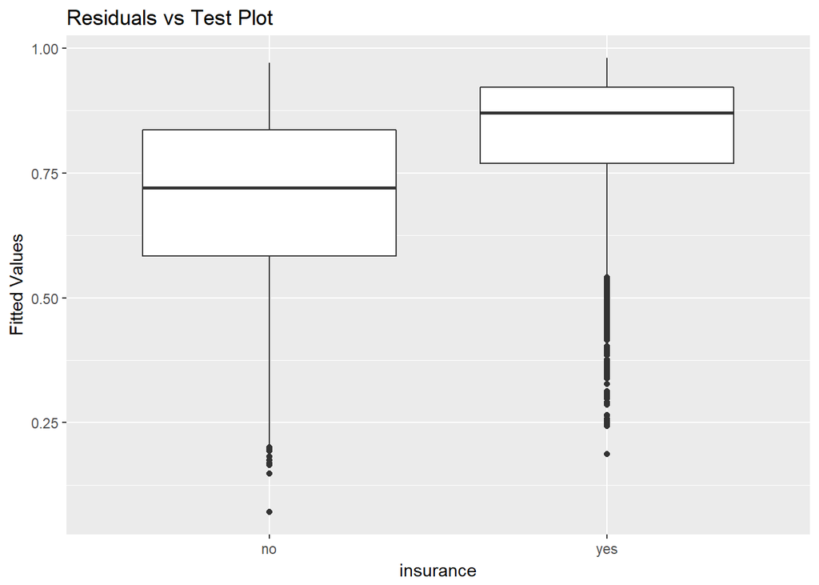

```r
(plot1 <- qplot(insurance, model4$fitted.values, geom = "boxplot", data=training)+labs(y="Fitted Values")+ggtitle("Residuals vs Test Plot"))
```

The Box Plot for insurance factor variable reveals a lot of outliers when compared with fitted values.

# 4.7 ROC Curve:

To assess the predictive ability of the model we use ROC curve and calculate the AUC(Area under curve) which are typical performance measurementsfor a binary classifier.

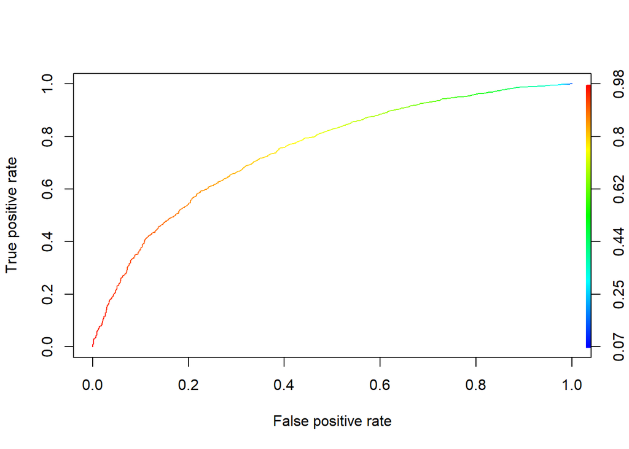

```r
pred<- predict(model4, training, type= 'response')
pred<- prediction(pred, training$insurance)
eval<- performance(pred,'tpr','fpr')
plot(eval, colorize = TRUE)
```

The ROC is a curve generated by plotting the true positive rate (TPR) against the false positive rate (FPR) at various threshold settings while the AUC is the area under the ROC curve.

# 4.8 Assesing the predictive ability of the model:

```r
model.probs=predict(model4,training,type="response")

# misclassification error:train data
pred1<- ifelse(model.probs>0.5, 1, 0)
#Confusion Matrix
tab1<- table(Predicted= pred1, Actual= training$insurance)
tab1
```

```
##          Actual
## Predicted   no  yes
##         0  210  158
##         1 1056 4978
```

```r
# misclassification error:train data
trainerror<- 1- sum(diag(tab1))/ sum(tab1)
trainerror
```

```
## [1] 0.1896282
```

```r
#Accuracy of Training data
print(paste('Accuracy',1-trainerror))
```

```
## [1] "Accuracy 0.810371758825367"
```

```r
# Test Error
model.test=predict(model4,testing,type="response")

# misclassification error:test data
pred_test<- ifelse(model.test>0.5, 1, 0)
#Confusion Matrix
tab_test<- table(Predicted= pred_test, Actual = testing$insurance)
tab_test
```

```
##          Actual
## Predicted   no  yes
##         0   79   55
##         1  405 1861
```

```r
# misclassification error:test data
testerror<- 1- sum(diag(tab_test))/ sum(tab_test)
testerror
```

```
## [1] 0.1916667
```

```r
#Accuracy of Training data
print(paste('Accuracy',1-testerror))
```

```
## [1] "Accuracy 0.808333333333333"
```

The error rate for training is roughly 19% and accuracy is 81.03% which is very high compared to real time predictions.

After fitting the model with the testing data we can observe that the acccuracy is 80.833 % which indicates satisfactory goodness of fit of the model.

# 4.9 Area Under the Curve

```r
auc<- performance(pred,"auc")
auc <- auc@y.values[[1]]
auc
```

```
## [1] 0.7486046
```

As a rule of thumb, a model with good predictive ability should have an AUC closer to 1 (1 is ideal) than to 0.5 which is the case with model 4 having area under the curve as .7486046.

# 4.10 To Find the actual movement and predict whether person takes insurance or not

```r
predict(model4,newdata=data.frame(health= "yes",age=20,family=3,gender="female",education="bachelor",married="yes",selfemp="no"),data=testing,type="response")
```

```
##         1
## 0.9142104
```

As can be seen we can see the actual movement of whether the person has insurance or not by creating a new dataframe. Suppose a person walks into hospital with

health = yes

age=20

family=3

gender=female

education=bachelor

married=yes

selfemp=no

# 5 Conclusion

This feature can be widely used by the insurance companies to predict whether the customer has health insurance or not. This would in turn help to infer the potential insurance buyers and help the companies to target the right audience to get maximum health insurance sales.